# Asking the right questions

Jihyun Yoo

January 16, 2020

### How to exercise efficiently.

Exercise by body part helps efficiency and rest. Keeping exercise in un-recovered condition may occur overtraining syndrome such as fatigue, depression, insomnia. Dr. Isratel, an exercise specialist, said 20 sets by body apart per week is good. Based on the researches, 6-12 times per set and 3 times per week for fast recovery body part and twice per week for slower recovery body part are proper.

reference : Exercise, protein metabolism, and muscle growth (Tipton, K. and Wolfe, R. 2001) Overtraining Syndrome: A Pratical Guide (Kreher, J. 2012) Dose-response relationship between weekly resistance training volume and increases in muscle mass: A systematic review and meta-analysis (Schoenfeld B, Ogborn D, Krieger J. 2017) The influence of frequency, intensity, volume and mode of strength training on whole muscle cross-sectional area in humans (Wernbom 2007)

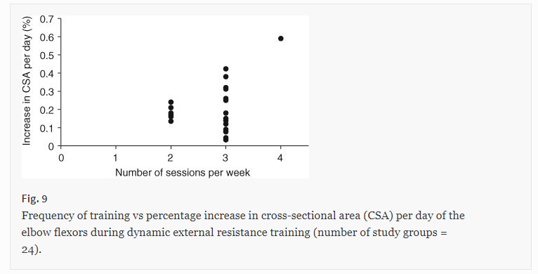

신체부위별로 날짜를 나눠서 함. 이유 ㅣ 효율성, 휴식 reference : exercise, protein metabolism, and muscle growth (Tipton, K. and Wolfe, R. 2001) 그렇지 않으면 Over training Syndrome. reference : Overtraining Syndrome: A Pratical Guide (Kreher, J 2012) 회복안된상태로 계속 운동하면 무기력증 집중력 저하 등 유발 가능 (Fatigue, Depression, Insomnia … ) 휴식에 무리주지 않는 선 : (intensity몇키로 , volume 몇개 : 무게x세트x반복수 , frequency빈도(매일.. ) )

refence Dose-response relationship between weekly resistance training volume and increases in muscle mass: A systematic review and meta-analysis. (Schoenfeld B, Ogborn D, Krieger J. 2017) : 세트수가 많아질수록 효과적 최대한의 볼륨은 미지수

Dr. Isratel 운동 전문가 : 부위당 주 20세트 세트당 6-12회 회복 빠르면 주 3회 느리면 2회 The influence of frequency, intensity, volume and mode of strength training on whole muscle cross-sectional area in humans. (Wernbom 2007)